# Spatial epidemiology

B. Raynor

6/27/2022

```r
rm(list = ls())
```

### Identifying clustering

**Definitions:**

- Cluster: an aggregation of cases grouped in place and time that are suspected to be greater than the number expected, even though the expected number may not be known [CDC](https://www.cdc.gov/csels/dsepd/ss1978/lesson1/section11.html#:~:text=Outbreak%20carries%20the%20same%20definition,number%20may%20not%20be%20known))
- Epidemic: an increase, often sudden, in the number of cases of a disease above what is normally expected in that population in that area [CDC](https://www.cdc.gov/csels/dsepd/ss1978/lesson1/section11.html#:~:text=Outbreak%20carries%20the%20same%20definition,number%20may%20not%20be%20known))
- Outbreak: Same as an epidemic, but is often used for a more limited geographic area [CDC](https://www.cdc.gov/csels/dsepd/ss1978/lesson1/section11.html#:~:text=Outbreak%20carries%20the%20same%20definition,number%20may%20not%20be%20known))
- Hot spot: less strictly defined… [Lessler et al](https://www.ncbi.nlm.nih.gov/pmc/articles/PMC5462559/) “In infectious disease epidemiology, “hotspot” is frequently used to refer to areas of elevated disease burden or high transmission efficiency."

#### **scan statistic**

A statistic used to evaluate spatial/temporal clusters:  
*“The circular spatial scan statistic is defined through a large number of overlapping circles [18]. For each circle z, a log likelihood ratio LLR(z) is calculated, and the test statistic is defined as the maximum LLR over all circles. The scanning window will depend on the application”* -[Kulldorff et al](https://ij-healthgeographics.biomedcentral.com/articles/10.1186/1476-072X-8-58)

- Free online software Ricardo recommended [SaTScan](https://www.satscan.org/).
- [rflexscan R package](https://www.jstatsoft.org/article/view/v099i13)

Code below is adapted from [rflexscan](https://www.jstatsoft.org/article/view/v099i13) R package code and accompanying paper

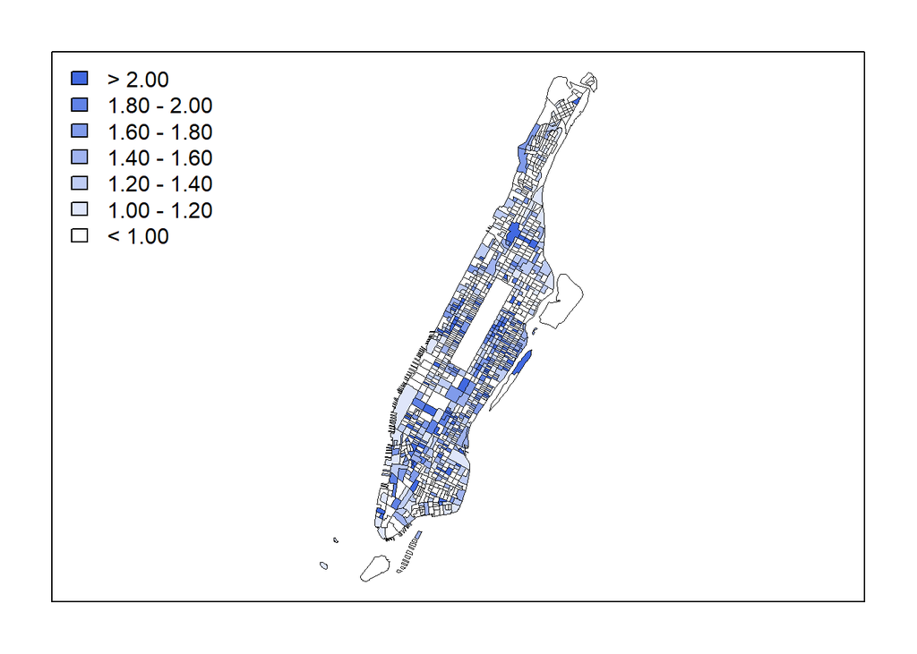

```r
library("rgdal")
library("spdep")
library("rflexscan")
library("RColorBrewer")

# for replication
set.seed(12345)


## ----load NYS cancer data-----------------------------------------------------
# Download data
temp <- tempfile()
download.file("https://www.satscan.org/datasets/nyscancer/NYS_Cancer.zip", temp)
unzip(temp, exdir = "NYS_Cancer")

nys <- readOGR("NYS_Cancer/NYSCancer_region.shp",
               stringsAsFactors = FALSE, verbose=FALSE)


## ----figure 1-----------------------------------------------------------------
manhattan <- nys[grep("36061", nys$DOHREGION),]
SIR <- manhattan$OBREAST / manhattan$EBREAST
nsteps <- 7
brks <- c(0, 1.0, 1.2, 1.4, 1.6, 1.8, 2, 10)
brks[1] <- 0
cols <- colorRampPalette(c("white","royal blue"))(nsteps)
grps <- as.ordered(cut(SIR, brks, include.lowest = TRUE))
par(mar = c(1, 1, 1, 1), oma = c(1, 1, 1, 1))
plot(manhattan, col=cols[unclass(grps)], lwd = 0.1)
box()
legend("topleft",
  legend = c("> 2.00", "1.80 - 2.00", "1.60 - 1.80",
    "1.40 - 1.60", "1.20 - 1.40", "1.00 - 1.20", "< 1.00"),
  fill=rev(cols), bty="n")
```

*“Figure 1: Standardized incidence ratios of breast cancer (female) in the Manhattan borough of New York City for the years 2005–2009 based on the 2010 census counts.”* [Otani and Takahashi, 2001](https://www.jstatsoft.org/article/view/v099i13)

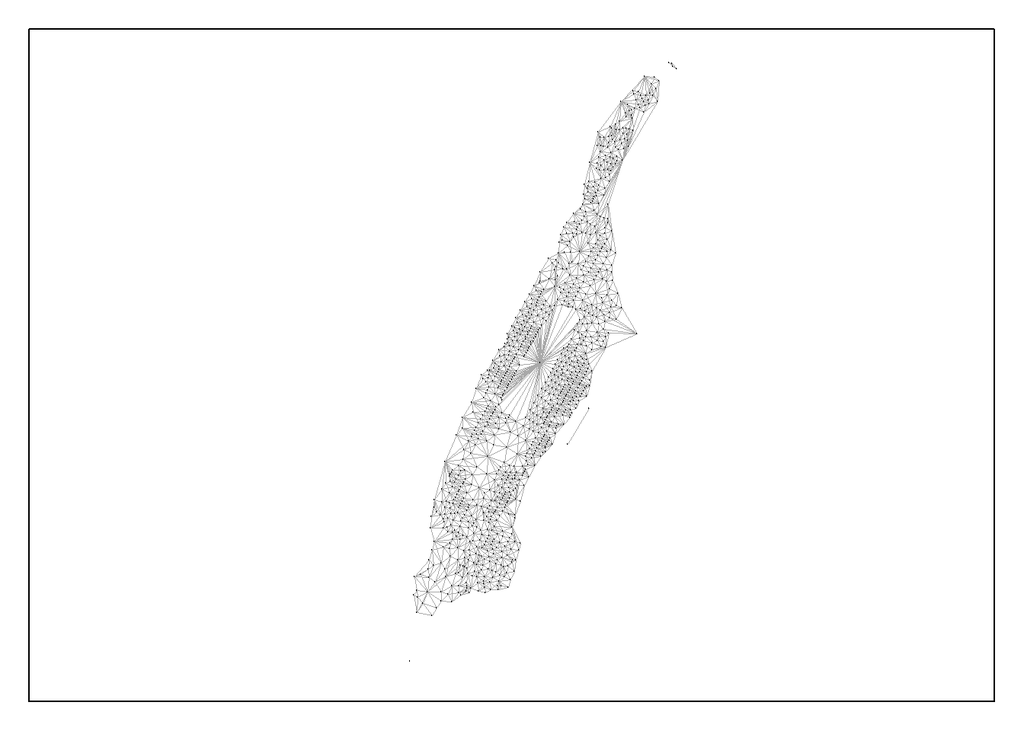

```r
## ----extract Manhattan data---------------------------------------------------
manhattan <- nys[startsWith(nys$DOHREGION, "36061"),]


## ----transformation-----------------------------------------------------------
coord <- data.frame(x=manhattan$LONGITUDE, y=manhattan$LATITUDE)
coordinates(coord) <- c("x", "y")
proj4string(coord) <- proj4string(manhattan)
coord <- spTransform(coord, CRS("+init=epsg:32618"))


## ----make a neighbors list----------------------------------------------------
nb <- poly2nb(manhattan, queen = T)


## ----figure 4-----------------------------------------------------------------
par(mar = c(0.5, 0.5, 0.5, 0.5), oma = c(0.5, 0.5, 0.5, 0.5))
plot(manhattan, border = "white", col = "white", lwd=0.2)
plot(nb, cbind(manhattan$LONGITUDE, manhattan$LATITUDE),
     col="darkgrey", add=TRUE, lwd=0.2, cex=0.1)
box()
```

*“Figure 4: Connections via poly2nb.”* [Otani and Takahashi, 2001](https://www.jstatsoft.org/article/view/v099i13)

```r
## ----run rflexscan------------------------------------------------------------
fls <- rflexscan(name = manhattan$DOHREGION,
  x = coord$x, y = coord$y, nb = nb,
  observed = manhattan$OBREAST, expected = manhattan$EBREAST)
summary(fls)
```

```
##
## Call:
## rflexscan(x = coord$x, y = coord$y, name = manhattan$DOHREGION,
##     observed = manhattan$OBREAST, expected = manhattan$EBREAST,
##     nb = nb)
##
## Clusters:
##     NumArea   MaxDist  Case  Expected     RR   Stats      P
## 1        10   616.844   133    67.012  1.985  25.536  0.001  ***
## 2         9   669.948    79    39.911  1.979  14.976  0.011    *
## 3         8   701.937    81    41.688  1.943  14.617  0.011    *
## 4        10   636.156    98    55.244  1.774  13.567  0.019    *
## 5        10   825.005    90    49.393  1.822  13.527  0.020    *
## 6         7   870.788    77    40.260  1.913  13.300  0.022    *
## 7         8   637.761   101    58.118  1.738  13.085  0.027    *
## 8         8   623.125    82    50.179  1.634   8.533  0.698
## 9         9   575.958    88    55.290  1.592   8.274  0.766
## 10        7   617.428    47    24.459  1.922   8.198  0.783
## 11        7   529.104    70    41.574  1.684   8.111  0.801
## 12        3   641.974    28    11.830  2.367   7.974  0.823
## 13        7  1145.401    69    42.682  1.617   6.881  0.977
## 14        9  1049.749    67    41.940  1.598   6.378  0.997
## 15        1     0.000    16     5.941  2.693   5.800  1.000
## ---
## Signif. codes:  0 '***' 0.001 '**' 0.01 '*' 0.05 '.' 0.1 ' ' 1
##
## Limit length of cluster: 15
## Number of areas: 982
## Total cases: 6219
## Coordinates: Cartesian
## Model: POISSON
## Scanning method: FLEXIBLE
## Statistic type: ORIGINAL
```

^printed out chart of the underlying statistics calculated

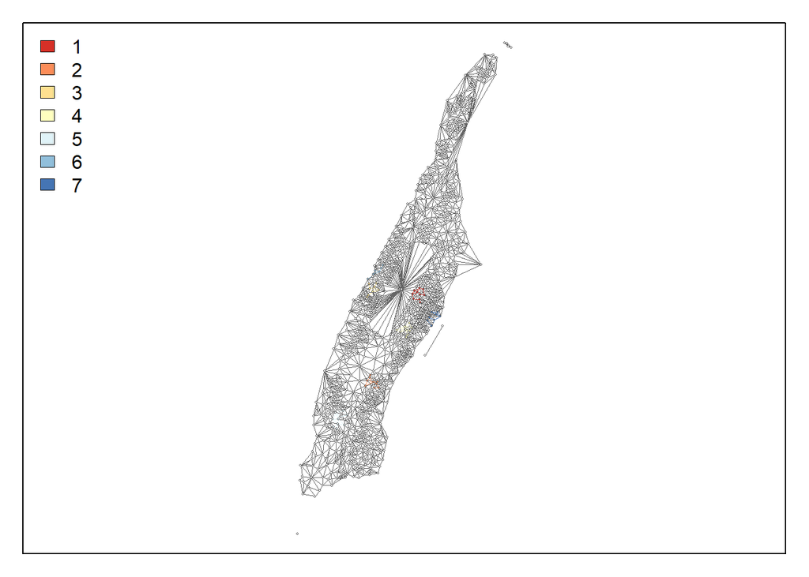

```r
## ----figure 6(a)--------------------------------------------------------------
par(mar = c(0.5, 0.5, 0.5, 0.5),
  oma = c(0.5, 0.5, 0.5, 0.5), lwd = 0.5, xaxt = 'n', yaxt = 'n')
plot(fls, rank = 1:7, edge.width = 0.5, col = brewer.pal(7, "RdYlBu"))
box(lwd = 1)
legend("topleft", legend = 1:7, fill = brewer.pal(7, "RdYlBu"), bty="n")
```

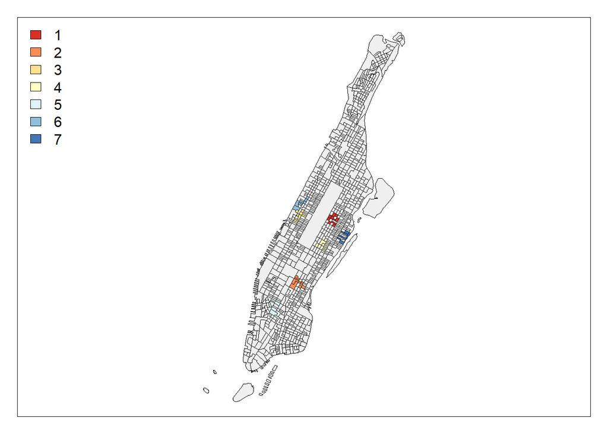

```r
## ----figure 6(b)--------------------------------------------------------------
par(mar = c(0.5, 0.5, 0.5, 0.5),
    oma = c(0.5, 0.5, 0.5, 0.5), xaxt = 'n', yaxt = 'n')
choropleth(manhattan, fls, rank = 1:7, col = brewer.pal(7, "RdYlBu"))
legend("topleft", legend = 1:7, fill = brewer.pal(7, "RdYlBu"), bty="n")
```

#### **Spatial relative risk**

- Relative risk compares the risk of a health event (disease, injury, risk factor, or death) among one group with the risk among another group. CDC
- Spatial relative risk is the ratio of densities describing spatial distribution of cases and controls. [Fernando and Hazelton, 2014](https://www.sciencedirect.com/science/article/abs/pii/S1877584513000555)

The following code is adapted from a [tutorial](https://onlinelibrary.wiley.com/doi/10.1002/sim.7577) using the sparr R package and calculates RR based on KDE (same method used to find HR last week applied in a different context)

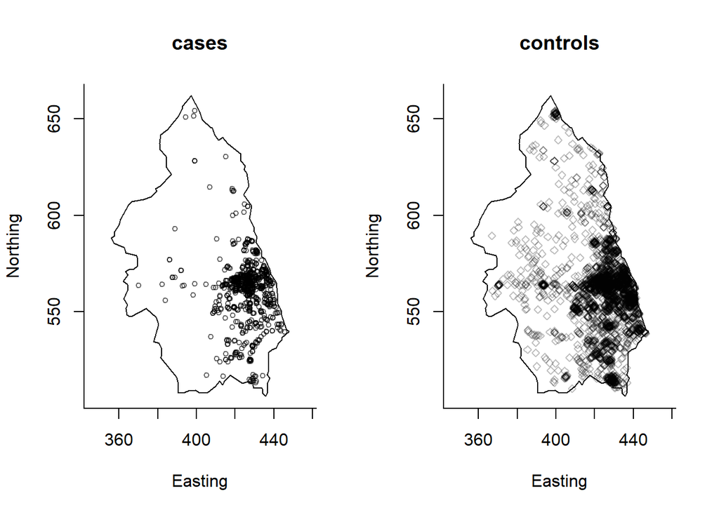

```r
### Section 1 ###
library("sparr")

#-- Figure 1
data(pbc)
pbccas <- split(pbc)$case
pbccon <- split(pbc)$control

par(mfrow=c(1,2))
plot(pbccas,cex=.7,main="cases");box(bty="l");axis(1);axis(2)
title(ylab="Northing",xlab="Easting")
plot(pbccon,cex=.7,pch=5,main="controls");box(bty="l");axis(1);axis(2)
title(ylab="Northing",xlab="Easting")
```

*Figure 1: Primary biliary cirrhosis cases and sampled at-risk controls in a geographical region of northeast England* [Davies et al](https://onlinelibrary.wiley.com/doi/10.1002/sim.7577)

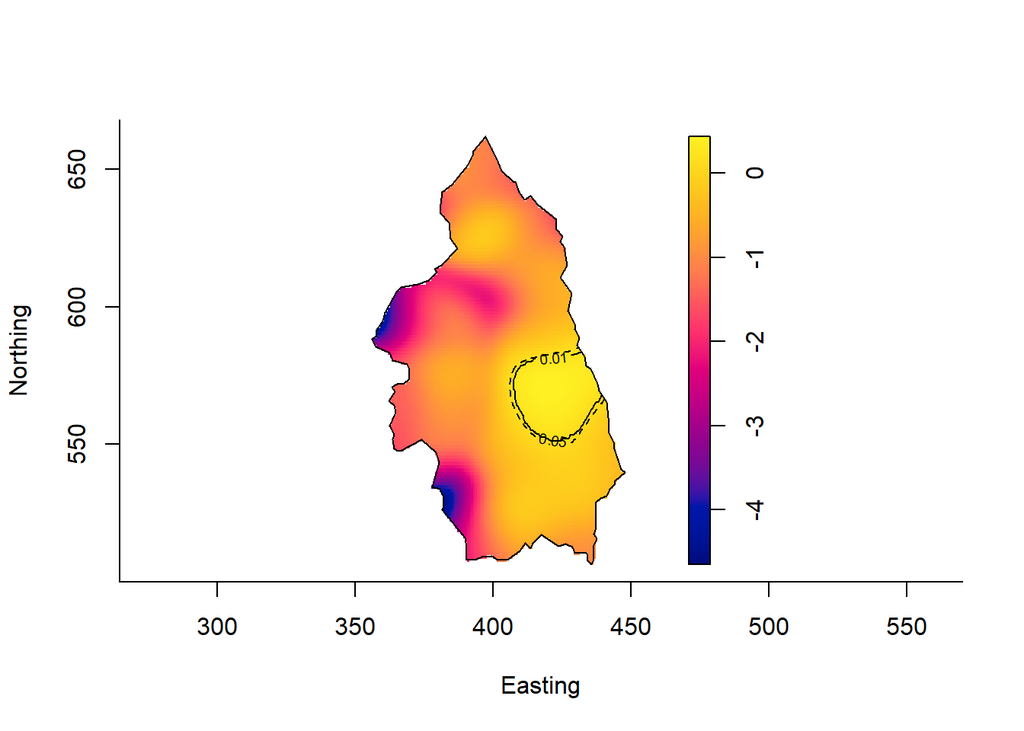

```r
#set common bandwith
hfix <- LSCV.risk(f=pbccas,g=pbccon, verbose = FALSE)

#compute fixed bandwidth estimate of PBC risk
f.tilde <- bivariate.density(pbccas,h0=hfix)
g.tilde <- bivariate.density(pbccon,h0=hfix)
rho.tilde <- risk(f=f.tilde,g=g.tilde)
pval.tilde <- tolerance(rs=rho.tilde,method="MC",ITER=200, verbose=FALSE)

# figure 5
plot(rho.tilde,xlab="Easting",ylab="Northing")
tol.contour(pim=pval.tilde,levels=c(0.01,0.05),lty=1:2,add=TRUE) #-- Figure 5 (right)
```

*Figure 5: Fixed-bandwidth spatial log-relative risk surfaces of the primary biliary cirrhosis (PBC) data estimated using sparr. Depicted is the recomputed estimate based on a jointly optimal, common case-control bandwidth found using LSCV.risk, as well as tolerance contours depicting significantly elevated risk of PBC calculated by Monte-Carlo simulations using tolerance. LSVC, least squares cross-validation* [Davies et al](https://onlinelibrary.wiley.com/doi/10.1002/sim.7577)

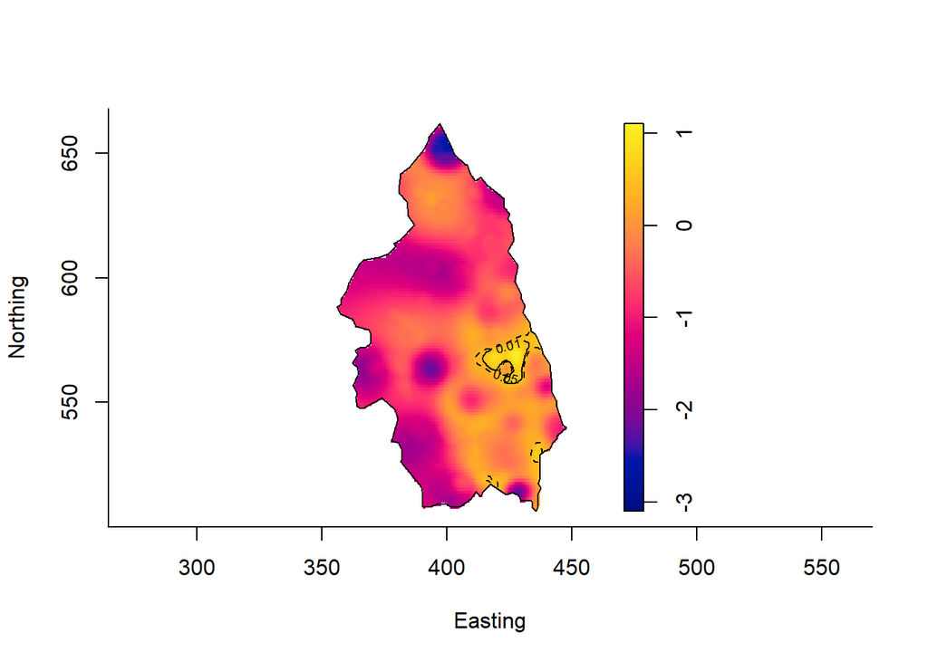

```r
#Adaptive bandwidth
hpilot.f <- BOOT.density(pbccas, verbose=FALSE)
hpilot.g <- BOOT.density(pbccon, verbose=FALSE)
h0 <- OS(pbc,nstar="geometric")
rho.hat1 <- risk(f=pbccas,g=pbccon,h0=h0,adapt=TRUE,hp=c(hpilot.f,hpilot.g),tolerate=TRUE)

plot(rho.hat1,zlim=c(-3.1,1.1),tol.args=list(levels=c(0.01,0.05),lty=1:2),xlab="Easting",ylab="Northing") #-- Figure 6 (left)
```

*Figure 6: Adaptive bandwidth spatial log-relative risk surfaces of the primary biliary cirrhosis (PBC) data estimated using sparr, withasymptotic (ASY) tolerance contours displayed. Method- an asymmetric estimate based on bootstrap-estimated pilot bandwidths and an over smoothing global bandwidth calculated using the pooled data.* [Davies et al](https://onlinelibrary.wiley.com/doi/10.1002/sim.7577)

### Identifying spatial autocorrelation

**Definitions:**

- Instead of a given variable (attribute) being distributed randomly across space, positive spatial autocorrelation indicates that spatially adjacent observations tend to have more similar data values [Haining 2001](https://www.sciencedirect.com/science/article/pii/B0080430767025110)

#### **Moran’s I**

Moran’s I is a statistic that measures spatial autocorrelation. [More info](https://www.statisticshowto.com/morans-i/).

[Tutorial source](https://mgimond.github.io/Spatial/spatial-autocorrelation-in-r.html)

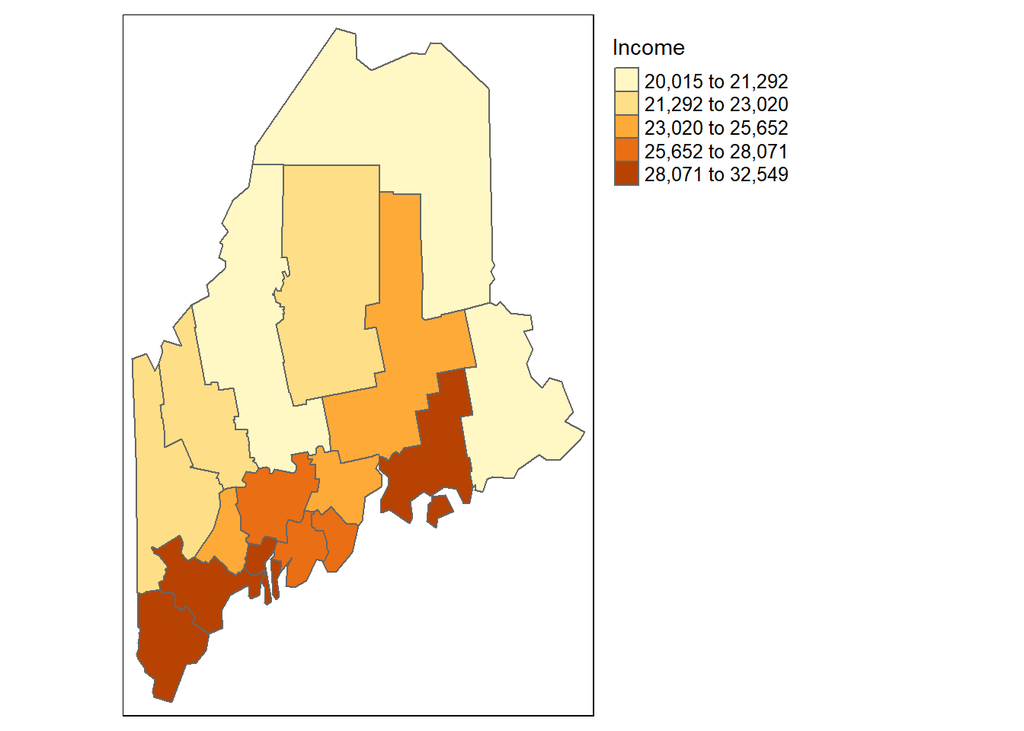

```
##
##  Moran I test under randomisation
##
## data:  s1$Income
## weights: lw
##
## Moran I statistic standard deviate = 2.2472, p-value = 0.01231
## alternative hypothesis: greater
## sample estimates:
## Moran I statistic       Expectation          Variance
##        0.28281108       -0.06666667        0.02418480
```

```
##
##  Monte-Carlo simulation of Moran I
##
## data:  s1$Income
## weights: lw
## number of simulations + 1: 600
##
## statistic = 0.28281, observed rank = 588, p-value = 0.02
## alternative hypothesis: greater
```

```r
library(tmap)
library(spdep)

load(url("https://github.com/mgimond/Spatial/raw/main/Data/moransI.RData"))

#visualize income distribution
map1<- tm_shape(s1) +
  tm_polygons(style="quantile", col ="Income") +
  tm_legend(outside = TRUE, text.size = .8)

#define neigbors
nb <- poly2nb(s1, queen=TRUE)

#Assign weights to neigboring polygons
lw <- nb2listw(nb, style="W", zero.policy=TRUE)

#compute average neighbor income value for each polygon
Inc.lag <- lag.listw(lw, s1$Income)

#calculate moran's I statistic
I1 <- moran.test(s1$Income,lw) # analytic solution for p-val

#Monte Carlo sim value for p-value
I2 <- moran.mc(s1$Income, lw, nsim=599)


map1; I1; I2
```

#### **Oden’s Ipop**

Oden’s I is an adjustment to Moran’s I that takes into account the underlying population density [Oden, 1995](https://pubmed.ncbi.nlm.nih.gov/7701154/). -no real code for this online… need to look up the derivation and code manually. Will do when I have more time.